# Data Mining with `R`

- About this course
- Acknowledgements
- Introduction
- Introduction and Data Used
- Descriptive Statistics
- Reduction of Data Dimensions
- Introduction
- MDS
- PCA and EFA
- CA
- Clustering
- Introduction
- HC
- NHC
- GMM
- Classification
- Introduction
- Logit recalls
- LDA and QDA
- KNN
- CTREE
- SVM
- Prediction
- Introduction
- LM
- RTREE
- Bootstrap Techniques

# Linear Model Variations (LM)

# Introduction

We now proceed to compare the results from using different alternative fitting techniques for a linear model. We do this using some simulated data with many independent variables, the first of which is highly correlated with some of the others:

```r
# Generate simulate data
set.seed(10)
n <- 1000
p <- 100
X <- data.frame(matrix(runif(n*p), nrow = n, ncol = p))
# Give names to data columns
names(X) <- paste("x", 1:ncol(X), sep = "")
# The first column is really correlated with the columns from 2 to 5.
X$x1 <- X$x2 + 2*X$x3 + 3*X$x4 - 4*X$x5 + rnorm(n, sd = .000001)
# The model for dependent variable
X$y <- 4 + 0.2*X$x1 + .5*X$x2 - .9*X$x3 + X$x4 - 0.5*X$x5 + 0.2*X$x6 + rnorm(n, mean = 0, sd = 1)

dt <- X
rm(X)
```

Since in above data frame only the columns from 1 to 6 and 101 are really correlated, a scatterplot matrix of these columns (along with a few of other columns) can be useful to show the relations between variables:

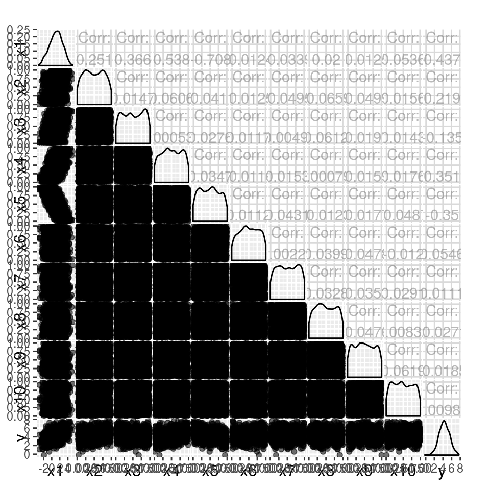

```r
require(ggplot2)
require(GGally)
ggpairs(data = dt, columns = c(1:10,101), mapping = aes(alpha = 0.3))
```

And some test on collinearity:

```r
# Collinearity test
X <- as.matrix(dt[,1:10])
require(Matrix)
rankMatrix(X)
```

```
## [1] 10
## attr(,"method")
## [1] "tolNorm2"
## attr(,"useGrad")
## [1] FALSE
## attr(,"tol")
## [1] 2.220446e-13
```

```r
try(solve(t(X)%*%X))
```

```
##                x1            x2            x3            x4            x5            x6            x7
## x1   9.877486e+08 -9.877487e+08 -1.975497e+09 -2.963246e+09  3.950995e+09  9.269590e+01 -1.178296e+01
## x2  -9.877487e+08  9.877487e+08  1.975497e+09  2.963246e+09 -3.950995e+09 -9.269741e+01  1.178213e+01
## x3  -1.975497e+09  1.975497e+09  3.950995e+09  5.926492e+09 -7.901989e+09 -1.853931e+02  2.356500e+01
## x4  -2.963246e+09  2.963246e+09  5.926492e+09  8.889737e+09 -1.185298e+10 -2.780888e+02  3.534759e+01
## x5   3.950995e+09 -3.950995e+09 -7.901989e+09 -1.185298e+10  1.580398e+10  3.707821e+02 -4.713357e+01
## x6   9.269590e+01 -9.269741e+01 -1.853931e+02 -2.780888e+02  3.707820e+02  1.107515e-02 -1.325542e-03
## x7  -1.178296e+01  1.178213e+01  2.356499e+01  3.534759e+01 -4.713357e+01 -1.325542e-03  1.027586e-02
## x8  -4.469485e+01  4.469417e+01  8.938788e+01  1.340833e+02 -1.787805e+02 -1.895624e-03 -1.575938e-03
## x9  -9.667720e+01  9.667618e+01  1.933534e+02  2.900304e+02 -3.867101e+02 -1.065225e-03 -9.539636e-04
## x10  1.191522e+02 -1.191537e+02 -2.383055e+02 -3.574578e+02  4.766082e+02 -1.121475e-03 -1.463820e-03
##                x8            x9           x10
## x1  -4.469485e+01 -9.667720e+01  1.191522e+02
## x2   4.469418e+01  9.667618e+01 -1.191537e+02
## x3   8.938788e+01  1.933534e+02 -2.383055e+02
## x4   1.340833e+02  2.900304e+02 -3.574578e+02
## x5  -1.787805e+02 -3.867101e+02  4.766082e+02
## x6  -1.895624e-03 -1.065225e-03 -1.121475e-03
## x7  -1.575938e-03 -9.539636e-04 -1.463820e-03
## x8   1.099962e-02 -9.116572e-04 -1.275005e-03
## x9  -9.116572e-04  1.020844e-02 -2.058544e-03
## x10 -1.275005e-03 -2.058544e-03  1.092878e-02
```

Note that the $(\underline{X}^T \underline{X})^{-1}$ matrix has very high diagonal values. This is because of collinearity between predictors. This also will probably produce very high standard errors and very unstable parameter estimates (since the variance/covariance matrix of parameter estimates is equal to $\sigma^2 (\underline{X}^T \underline{X})^{-1}$).

To assess the relative predictive performances of the methods that will study, we split the dataset into training (75%) and test sets (25%):

```r
# Splits the data into training and test data frames
sel_train <- sample(1:nrow(dt), replace = FALSE, size = n*.75)
dt_train <- dt[sel_train, ]
dt_test <- dt[setdiff(1:n, sel_train), ]
```

## (1) Ordinary Least Squares (OLS)

This usually does not perform well for models with many independent variables and for models with highly correlated independent variables:

```r
ols_fit <- lm(y ~ ., data = dt_train)
summary(ols_fit)
```

```
##
## Call:
## lm(formula = y ~ ., data = dt_train)
##
## Residuals:
##     Min      1Q  Median      3Q     Max
## -2.8576 -0.6298 -0.0244  0.6235  3.2517
##
## Coefficients:
##               Estimate Std. Error t value Pr(>|t|)
## (Intercept)  4.555e+00  7.072e-01   6.440 2.32e-10 ***
## x1          -8.185e+03  3.969e+04  -0.206 0.836702
## x2           8.186e+03  3.969e+04   0.206 0.836684
## x3           1.637e+04  7.939e+04   0.206 0.836707
## x4           2.456e+04  1.191e+05   0.206 0.836693
## x5          -3.274e+04  1.588e+05  -0.206 0.836694
## x6           3.967e-01  1.380e-01   2.875 0.004172 **
## x7           1.044e-02  1.341e-01   0.078 0.937969
## x8          -3.143e-01  1.373e-01  -2.290 0.022353 *
## x9           4.646e-02  1.383e-01   0.336 0.736938
## x10         -9.437e-02  1.369e-01  -0.689 0.490882
## x11         -8.235e-02  1.337e-01  -0.616 0.538054
## x12         -1.933e-01  1.337e-01  -1.446 0.148711
## x13          2.338e-01  1.368e-01   1.709 0.087859 .
## x14         -6.622e-02  1.380e-01  -0.480 0.631555
## x15          1.972e-01  1.363e-01   1.447 0.148394
## x16          2.419e-01  1.315e-01   1.840 0.066265 .
## x17          1.829e-01  1.382e-01   1.323 0.186283
## x18          1.601e-01  1.360e-01   1.177 0.239623
## x19         -6.067e-02  1.379e-01  -0.440 0.660048
## x20          2.443e-02  1.383e-01   0.177 0.859897
## x21          1.705e-03  1.383e-01   0.012 0.990166
## x22          1.657e-01  1.344e-01   1.233 0.217951
## x23         -1.286e-02  1.360e-01  -0.095 0.924688
## x24         -1.132e-01  1.333e-01  -0.849 0.395967
## x25          1.537e-01  1.406e-01   1.093 0.274823
## x26         -2.078e-01  1.327e-01  -1.566 0.117871
## x27         -6.218e-02  1.419e-01  -0.438 0.661391
## x28          4.130e-02  1.384e-01   0.298 0.765480
## x29         -3.009e-01  1.359e-01  -2.214 0.027199 *
```

[output cut: 62 more lines]

```
## x92         -9.042e-03  1.362e-01  -0.066 0.947090
## x93          1.102e-01  1.370e-01   0.804 0.421482
## x94          2.375e-01  1.396e-01   1.702 0.089259 .
## x95         -8.374e-02  1.324e-01  -0.632 0.527374
## x96          1.280e-02  1.379e-01   0.093 0.926076
## x97         -5.123e-02  1.345e-01  -0.381 0.703411
## x98          7.947e-02  1.403e-01   0.567 0.571249
## x99         -1.248e-01  1.377e-01  -0.906 0.365199
## x100        -1.429e-02  1.323e-01  -0.108 0.914014
## ---
## Signif. codes:  0 '***' 0.001 '**' 0.01 '*' 0.05 '.' 0.1 ' ' 1
##
## Residual standard error: 1.002 on 649 degrees of freedom
## Multiple R-squared:  0.4237, Adjusted R-squared:  0.3349
## F-statistic: 4.771 on 100 and 649 DF,  p-value: < 2.2e-16
```

The model finds many non significant parameters; also, as expected, the standard errors of parameters are big. Anyway, $\hat{\sigma}^2 = 1.002$ means that the training residuals performs almost well.  
Notice also that the parameter estimates are very far from the true values.

However, to test the predictive performances of model, it must be applied on test data, with following results:

```r
mse <- summary((predict(ols_fit, newdata = dt_test) - dt_test$y)^2)
print(mse)
```

```
##     Min.  1st Qu.   Median     Mean  3rd Qu.     Max.
## 0.000055 0.108300 0.472800 1.117000 1.410000 7.904000
```

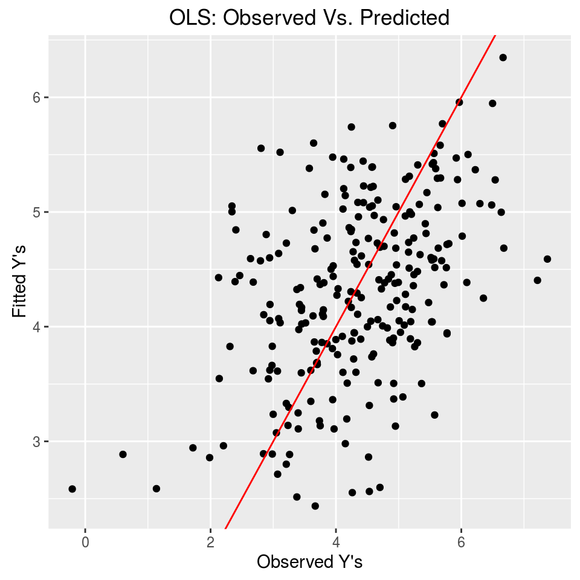

```r
ggp <- ggplot(data = data.frame(fit=predict(ols_fit, newdata = dt_test), obs=dt_test$y), mapping = aes(x = obs, y = fit)) +
  geom_point() +
  ggtitle("OLS: Observed Vs. Predicted") +
  xlab("Observed Y's") + ylab("Fitted Y's") +
  geom_abline(slope = 1,intercept = 0, colour="red")
print(ggp)
```

The resuduals on test data show a greater variability with respect to residuals on train data.

Maybe, by searching a more parsimonious model we could obtain better predictions.

## (2) Forward Stepwise Selection

Forward stepwise selection begins with a model containing no predictors, and then adds one predictor at a time to the model until all of the “significant” predictors are in the model. The “Forward stepwise” selection procedure try to minimize an optimality criterion function (often AIC), and acts as follows:

1. Start from an “initial model” (often the “only mean, no predictors” model) and calculates the criterion function
2. Add the predictor that best reduces the criterion function
3. Add another predictor (if exists) that best reduces the criterion function
4. Check if the previously inserted predictors can be removed from model (i.e., check if removing some previously inserted variables the criterion function reduces); remove them one by one
5. Are there other predictors that if added to model reduce the criterion function? If Yes, then go to step 3.
6. Exit

While computationally advantageous, for example, with respect to best subset selection, the Forward Stepwise method does not guarantee to find the best possible model out of all models containing subsets of the $p$ predictors. For instance, suppose that in a given dataset with $p = 3$ predictors, the best possible one-variable model contains $X1$, and the best possible mode is a two-variable one that contains $X2$ and $X3$. Then forward stepwise selection could fail to select the best possible two-variable model, because at the second step the model couldn’t be able to remove $X1$.

```r
require(MASS)
```

```r
m_init <- lm(y ~ 1, data = dt_train)
upr <- paste("x",1:100, sep="", collapse=" + ")
upr <- as.formula(paste("~",upr))
forw_fit <- stepAIC(m_init, scope = list(upper = upr, lower = ~ 1) , direction = "forward", trace = FALSE)
summary(forw_fit)
```

```
##
## Call:
## lm(formula = y ~ x1 + x3 + x59 + x2 + x6 + x32 + x82 + x29 +
##     x30 + x4 + x68 + x8 + x45 + x83 + x13 + x94 + x51 + x38 +
##     x26 + x16 + x40 + x86, data = dt_train)
##
## Residuals:
##      Min       1Q   Median       3Q      Max
## -2.81774 -0.66472 -0.07127  0.64822  2.76597
##
## Coefficients:
##             Estimate Std. Error t value Pr(>|t|)
## (Intercept)  4.25664    0.30106  14.139  < 2e-16 ***
## x1           0.38963    0.03165  12.309  < 2e-16 ***
## x3          -1.36485    0.13707  -9.957  < 2e-16 ***
## x59         -0.43296    0.12458  -3.475 0.000540 ***
## x2           0.45413    0.13314   3.411 0.000683 ***
## x6           0.41745    0.12770   3.269 0.001130 **
## x32          0.36477    0.12736   2.864 0.004304 **
## x82          0.27842    0.12636   2.203 0.027878 *
## x29         -0.27267    0.12554  -2.172 0.030175 *
## x30         -0.29358    0.12677  -2.316 0.020847 *
## x4           0.27725    0.15530   1.785 0.074635 .
## x68         -0.27851    0.12356  -2.254 0.024493 *
## x8          -0.27003    0.12767  -2.115 0.034763 *
## x45         -0.22180    0.12494  -1.775 0.076288 .
## x83          0.20777    0.12362   1.681 0.093257 .
## x13          0.21798    0.12708   1.715 0.086720 .
## x94          0.25165    0.13007   1.935 0.053420 .
## x51         -0.19979    0.12427  -1.608 0.108334
## x38         -0.18395    0.12632  -1.456 0.145782
## x26         -0.19114    0.12303  -1.554 0.120716
## x16          0.20035    0.12395   1.616 0.106452
## x40          0.20036    0.12665   1.582 0.114073
## x86          0.17500    0.12319   1.421 0.155883
## ---
## Signif. codes:  0 '***' 0.001 '**' 0.01 '*' 0.05 '.' 0.1 ' ' 1
##
## Residual standard error: 0.9808 on 727 degrees of freedom
## Multiple R-squared:  0.3815, Adjusted R-squared:  0.3627
## F-statistic: 20.38 on 22 and 727 DF,  p-value: < 2.2e-16
```

The predictive performaces are:

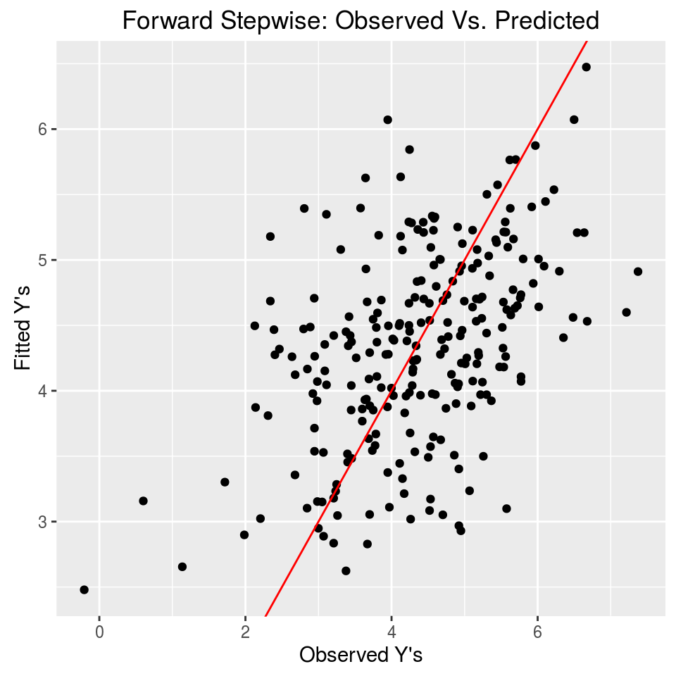

```r
# Plots Observed Vs. Predicted values
ggp <- ggplot(data = data.frame(fit=predict(forw_fit, newdata = dt_test), obs=dt_test$y), mapping = aes(x = obs, y = fit)) +
  geom_point() +
  ggtitle("Forward Stepwise: Observed Vs. Predicted") +
  xlab("Observed Y's") + ylab("Fitted Y's") +
  geom_abline(slope = 1,intercept = 0, colour="red")
print(ggp)
```

```r
y_pred_forw <- predict(forw_fit, newdata = dt_test)
mse <- rbind(mse, summary((y_pred_forw - dt_test$y)^2))
rownames(mse)[nrow(mse)] <- "Forward"
mse
```

```
##              Min. 1st Qu. Median  Mean 3rd Qu.  Max.
## mse     5.502e-05 0.10830 0.4728 1.117   1.410 7.904
## Forward 3.975e-08 0.08743 0.5400 1.066   1.312 8.055
```

In this case the Forward stepwise selection gives almost good results. The best model selected is a few “redundant” (at least with respect to best subset model), but it shows good predictive performances.

## (3) Backward Stepwise Selection

Unlike forward stepwise selection, backward stepwise selection begins with the full least squares model containing all predictors, and then iteratively removes the least useful predictor, one-at-a-time. Also the “Backward stepwise” selection procedure try to minimize an optimality criterion function (often AIC), and acts as follows:

1. Start from an “initial model” (often the “all predictors” model) and calculate the criterion function
2. Remove the predictor that best reduces the criterion function
3. Remove another predictor (if exists) that best reduces the criterion function
4. Check if the previously removed predictors can be re-inserted into model (i.e., check if adding some previously removed variables the criterion function reduces); add them one by one
5. Are there other predictors that when removed from model reduce the criterion function? If Yes, then go to step 3.
6. Exit

Like forward stepwise selection, backward stepwise selection does not guarantee to yield the best model containing a subset of the $p$ predictors. In contrast to forward stepwise, Backward selection requires that the sample size $n$ is larger than the number of variables $p$ (so that the full model can be fit). Anyway, the Backward stepwise procedure usually obtains better results with respect to the Forward one.

```r
m_init <- lm(y ~ ., data = dt_train)
back_fit <- stepAIC(m_init, scope = list(upper = ~ ., lower = ~ 1) , direction = "backward", trace = FALSE)
summary(back_fit)
```

```
##
## Call:
## lm(formula = y ~ x1 + x2 + x4 + x5 + x6 + x8 + x13 + x15 + x16 +
##     x22 + x26 + x29 + x30 + x32 + x40 + x45 + x51 + x59 + x68 +
##     x69 + x75 + x81 + x82 + x83 + x86 + x87 + x94, data = dt_train)
##
## Residuals:
##      Min       1Q   Median       3Q      Max
## -2.95194 -0.67439 -0.03727  0.63505  2.78238
##
## Coefficients:
##             Estimate Std. Error t value Pr(>|t|)
## (Intercept)  3.72417    0.34235  10.878  < 2e-16 ***
## x1          -0.28925    0.06055  -4.777 2.16e-06 ***
## x2           1.15321    0.14540   7.931 8.27e-15 ***
## x4           2.29935    0.21682  10.605  < 2e-16 ***
## x5          -2.69593    0.27440  -9.825  < 2e-16 ***
## x6           0.39360    0.12794   3.076 0.002174 **
## x8          -0.26176    0.12741  -2.054 0.040289 *
## x13          0.22865    0.12721   1.797 0.072691 .
## x15          0.18793    0.12723   1.477 0.140092
## x16          0.20962    0.12403   1.690 0.091441 .
## x22          0.19069    0.12422   1.535 0.125209
## x26         -0.17762    0.12301  -1.444 0.149190
## x29         -0.28447    0.12550  -2.267 0.023705 *
## x30         -0.27786    0.12661  -2.195 0.028515 *
## x32          0.38857    0.12768   3.043 0.002425 **
## x40          0.19775    0.12652   1.563 0.118505
## x45         -0.20859    0.12499  -1.669 0.095582 .
## x51         -0.20463    0.12404  -1.650 0.099448 .
## x59         -0.43285    0.12513  -3.459 0.000573 ***
## x68         -0.26278    0.12345  -2.129 0.033630 *
## x69          0.19662    0.12657   1.553 0.120755
## x75          0.19254    0.12738   1.511 0.131099
## x81         -0.17202    0.12239  -1.406 0.160285
## x82          0.27708    0.12636   2.193 0.028648 *
## x83          0.21754    0.12327   1.765 0.078040 .
## x86          0.19022    0.12308   1.546 0.122650
## x87          0.18358    0.12540   1.464 0.143625
## x94          0.23738    0.12970   1.830 0.067616 .
## ---
## Signif. codes:  0 '***' 0.001 '**' 0.01 '*' 0.05 '.' 0.1 ' ' 1
##
## Residual standard error: 0.978 on 722 degrees of freedom
## Multiple R-squared:  0.3892, Adjusted R-squared:  0.3664
## F-statistic: 17.04 on 27 and 722 DF,  p-value: < 2.2e-16
```

The predictive performaces:

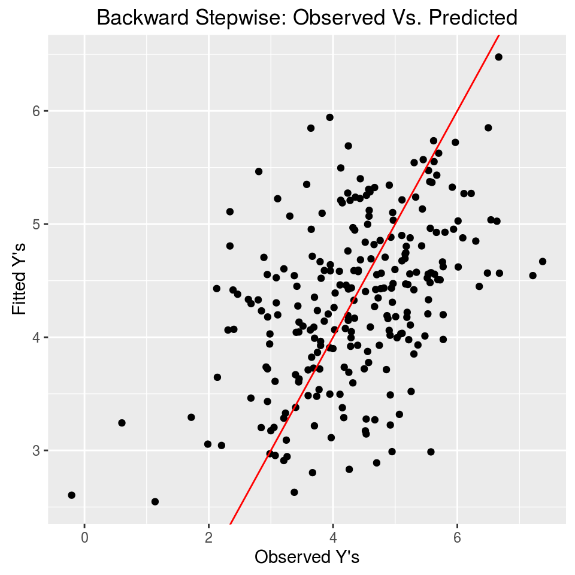

```r
# Plots Observed Vs. Predicted values
ggp <- ggplot(data = data.frame(fit=predict(back_fit, newdata = dt_test), obs=dt_test$y), mapping = aes(x = obs, y = fit)) +
  geom_point() +
  ggtitle("Backward Stepwise: Observed Vs. Predicted") +
  xlab("Observed Y's") + ylab("Fitted Y's") +
  geom_abline(slope = 1,intercept = 0, colour="red")
print(ggp)
```

```r
y_pred_back <- predict(back_fit, newdata = dt_test)
mse <- rbind(mse, summary((y_pred_back - dt_test$y)^2))
rownames(mse)[nrow(mse)] <- "Backward"
mse
```

```
##               Min. 1st Qu. Median  Mean 3rd Qu.  Max.
## mse      5.502e-05 0.10830 0.4728 1.117   1.410 7.904
## Forward  3.975e-08 0.08743 0.5400 1.066   1.312 8.055
## Backward 9.430e-05 0.07594 0.4815 1.082   1.434 7.904
```

In this case, Backward Stepwise yields a few worse results than Forward one.

## (4) Best Subset Selection

In best subset selection we fit a separate least squares regression for each possible combination of the $p$ predictors. That is, we fit all models that contain exactly one predictor, all models that contain exactly two predictors, and so forth. We then identify the model that is “best”" with respect to a given optimality criterion (typically, adjusted R-squared, BIC, AIC, or Mallows’ Cp).

While best subset selection is a simple and conceptually appealing approach, it suffers from computational limitations. The number of possible models that must be considered grows rapidly as the number of potential predictors increases. With $p$ = 10, there are approximately 1,000 possible models to consider, therefore it becomes computationally intractable for a number of variables not too big (around 40). Moreover, best subset selection does not perform well in situations where $p > n$, that is when the number of predictors is larger than the number of cases, as well as when some of the predictors are strongly correlated.

Anyway, the package `leaps` contains the `regsubsets()` function that implements the best subset approach:

```r
require(leaps)
```

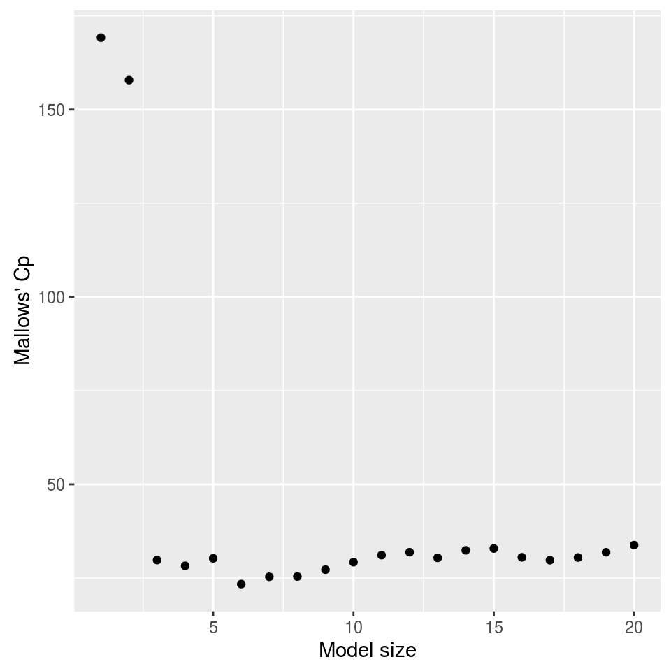

```r
# Performs a best-subset exhaustive (see 'method' parameter) model search
nvmax <- 20
dt_t <- dt_train
dt_train <- dt_train[, c(1:70,101)]
bs_fit <- regsubsets(x = dt_train[, 1:(ncol(dt_train)-1)], y = dt_train[, ncol(dt_train)], method = "exhaustive", nvmax = nvmax, really.big = TRUE)
l <- summary(bs_fit)

# Plots the BIC index
ggp <- ggplot(data = data.frame(size=1:nvmax, cp=l$cp), mapping = aes(x = size, y = cp)) +
  geom_point() +
  xlab("Model size") + ylab("Mallows' Cp")
print(ggp)
```

Note: Mallows’ $Cp = \frac{RSS_p}{s^2}-(n - 2p)$, where $s^2$ is the residual standard deviation calculated on most complete model, $p$ is the number of parameters estimated in model, and $n$ is the sample size.  
We then select best model according to $Cp$:

```r
# Selects the predictors of best model
bestfeat <- l$which[which.min(l$cp), ]
# Adds the dependent variable
bestfeat <- c(bestfeat[-1], TRUE)
```

Finally, we train and test the best model selected

```r
m_bestsubset <- lm(y ~ ., data = dt_train[, bestfeat])
summary(m_bestsubset)
```

```
##
## Call:
## lm(formula = y ~ ., data = dt_train[, bestfeat])
##
## Residuals:
##      Min       1Q   Median       3Q      Max
## -3.08455 -0.66908 -0.05118  0.70591  3.05696
##
## Coefficients:
##               Estimate Std. Error t value Pr(>|t|)
## (Intercept)  4.059e+00  1.485e-01  27.334  < 2e-16 ***
## x1           4.173e+03  3.781e+04   0.110  0.91215
## x2          -4.172e+03  3.781e+04  -0.110  0.91216
## x3          -8.347e+03  7.562e+04  -0.110  0.91214
## x4          -1.252e+04  1.134e+05  -0.110  0.91216
## x5           1.669e+04  1.512e+05   0.110  0.91215
## x6           3.837e-01  1.303e-01   2.945  0.00333 **
## ---
## Signif. codes:  0 '***' 0.001 '**' 0.01 '*' 0.05 '.' 0.1 ' ' 1
##
## Residual standard error: 1.013 on 743 degrees of freedom
## Multiple R-squared:  0.3255, Adjusted R-squared:  0.3201
## F-statistic: 59.76 on 6 and 743 DF,  p-value: < 2.2e-16
```

The model on train data seems to select correctly the variables that actually impact on dependent variable. However, almost all the parameters are very far from the true parameter values and show a very high p-value. This can depend on high multicollinearity.

Let’s see the predictive performances:

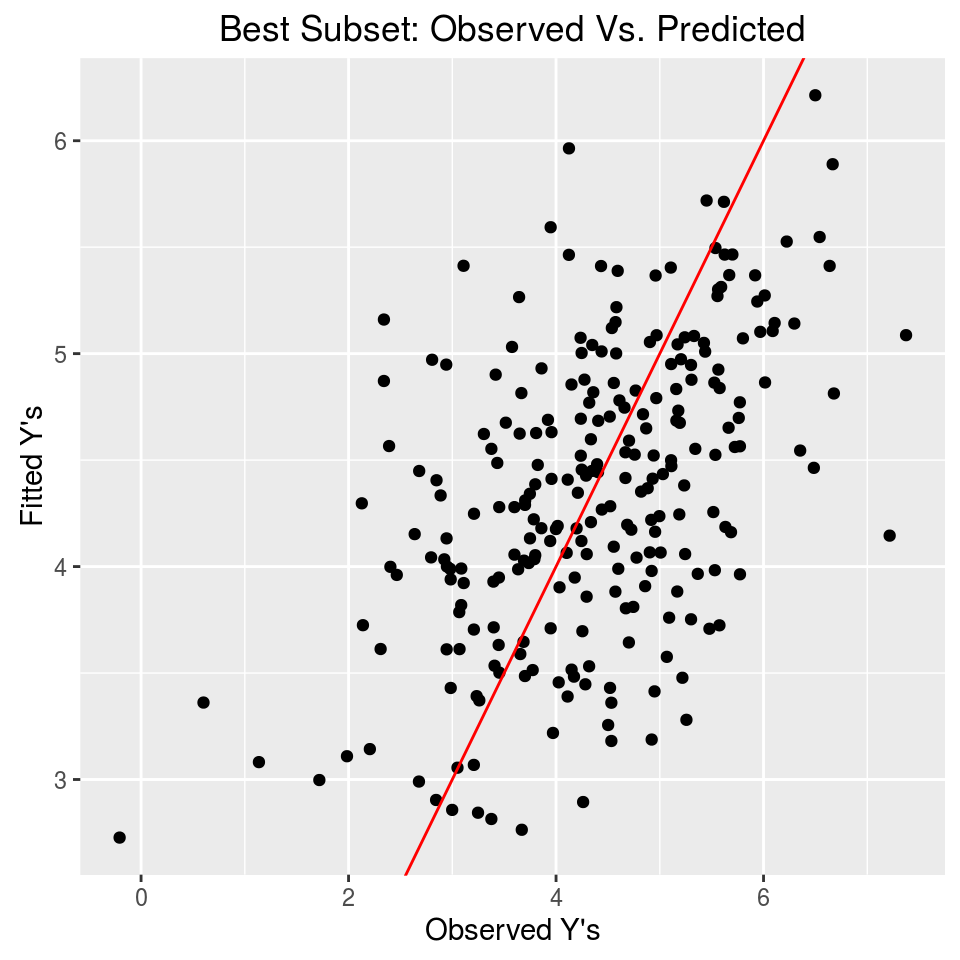

```r
# Plots Observed Vs. Predicted values
ggp <- ggplot(data = data.frame(fit=predict(m_bestsubset, newdata = dt_test), obs=dt_test$y), mapping = aes(x = obs, y = fit)) +
  geom_point() +
  ggtitle("Best Subset: Observed Vs. Predicted") +
  xlab("Observed Y's") + ylab("Fitted Y's") +
  geom_abline(slope = 1,intercept = 0, colour="red")
print(ggp)
```

```r
y_pred_bestsubset <- predict(m_bestsubset, dt_test[, bestfeat])
mse <- rbind(mse, summary((y_pred_bestsubset - dt_test$y)^2))
rownames(mse)[1] <- "OLS"
rownames(mse)[nrow(mse)] <- "Best subset"
mse
```

```
##                  Min. 1st Qu. Median   Mean 3rd Qu.  Max.
## OLS         5.502e-05 0.10830 0.4728 1.1170   1.410 7.904
## Forward     3.975e-08 0.08743 0.5400 1.0660   1.312 8.055
## Backward    9.430e-05 0.07594 0.4815 1.0820   1.434 7.904
## Best subset 3.138e-05 0.08001 0.4327 0.9901   1.257 9.426
```

```r
dt_train <- dt_t
rm(dt_t)
```

Best subset seems to predict better. This may depend on the big number of predictors selected from above methods, that produces an overfitting on data: the above methods predict well the train data, but not the test data, also if it arises from the same process (by construction).  
Note that this result can change if we use a different criterion to select the best model (for example, AIC or BIC instead of Mallows’ Cp).

## (5) Ridge Regression

When many predictors are available, and when high collinearity exists between predictors, then the estimates can become unstable and less reliable.

A method to solve this problem, is by fitting a model containing all $p$ predictors using a technique that “constraints” or “regularizes” the coefficient estimates, or equivalently, that shrinks the coefficient estimates towards zero. Shrinking the coefficient estimates has the effect of significantly reducing the coefficients’ variance. The best-known technique for shrinking the regression coefficients towards zero is ridge regression.

In ridge regression coefficients are estimated by minimizing a slightly different quantity with respect to least squares. In particular, the objective function in ridge regression is a penalized version of the sum of squared deviations used in least squares. The penalty (called a shrinkage penalty), is small when the coefficients are close to zero, and so it has the effect of shrinking the estimates towards zero. In the objective function we find a tuning parameter that regulates the amount of shrinkage.  
In mathematical form, the ridge regression search for the $\hat{\underline{\beta}}=(\beta_0, \beta_1, \dots, \beta_p)^T$ values that minimize the following modified least squares criterion:

$$\sum_{i=1}^n \left(y_i - \underline{x}_i^T\underline{\beta} \right)^2 + \lambda \sum_{j=1}^p \beta_j^2$$

Where $\lambda$ is the penalization parameter. The selection of a good value for $\lambda$ is critical, and it is typically carried out by cross-validation.

Ridge regression produces less variable and less correlated coefficient estimates at the cost of a slight increase in the estimation bias.  
Also ridge regression tends to “push toward zero” the estimated coefficients.  
Notice that ridge regression does not penalize the intercept term.

Ridge regression has been developed to overtake the problem induced by highly correlated predictors (so called multicollinearity). In fact, the least squares estimates of standard error of the coefficients can be expressed as $s^2/((n - 1) \cdot Var(x_j) \cdot 1/(1 - R_j)$, where $s^2$ is the residual variance, $Var(x_j)$ is the variance of $j$-th predictor, and $R_j$ is the determination coefficient of the regression of the $j$-th predictor on the remaining predictors. The factor $1/(1 - R_j)$ is called the variance inflation factor (VIF).

In our example, the VIF for the first predictor is given by:

```r
1/(1 - summary(lm(x1 ~ ., data = dt_train[,1:100]))$r.squared)
```

```
## [1] 3.015467e+12
```

which is very high! The most common threshold used for the VIF is 10.

In R, the `lm.ridge()` function is available inside the MASS package. This function performs ridge regression and gives tools to select the best value of $\lambda$:

```r
ridge_fit <- lm.ridge(y ~ ., data = dt_train, lambda = seq(0, 400, by = 0.01))
select(ridge_fit) ## Note: HKB and L-W are alternative estimators of ridge parameter
```

```
## modified HKB estimator is 2.894927e-07
## modified L-W estimator is 154.066
## smallest value of GCV  at 285.52
```

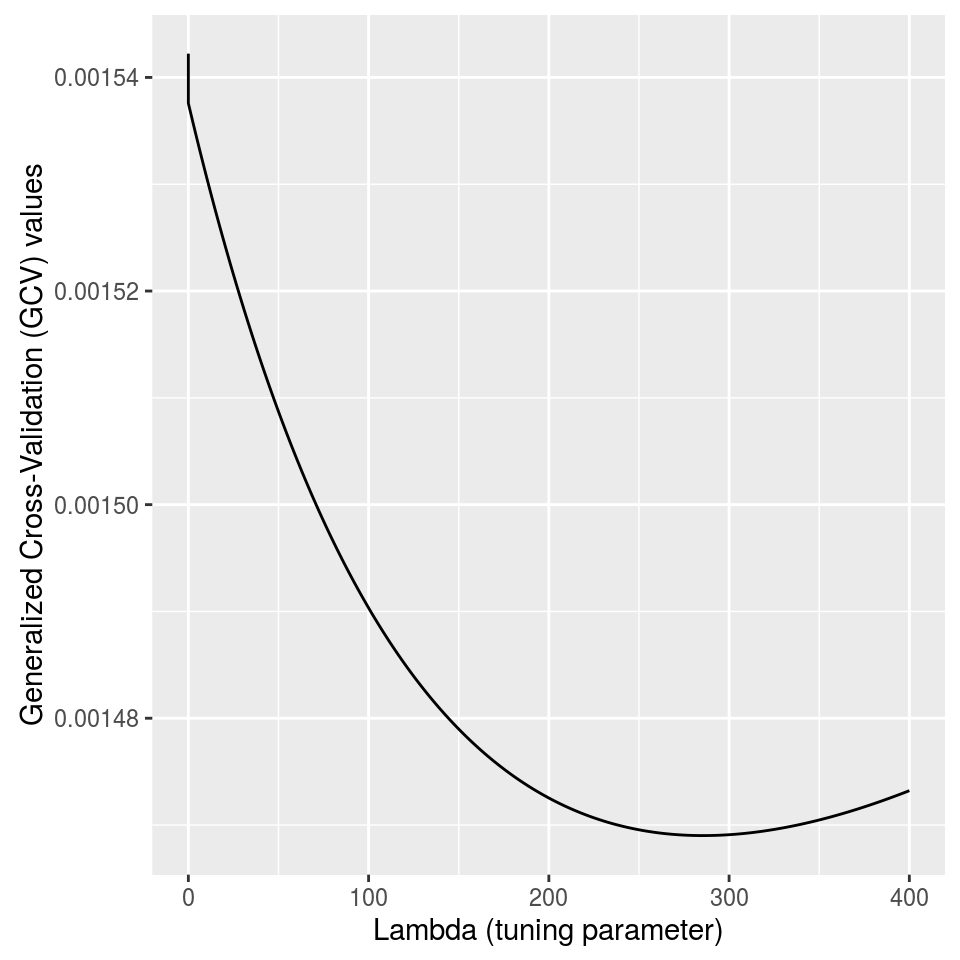

```r
# Plot of CV Lambda values with its RSS:
ggp <- ggplot(data = as.data.frame(ridge_fit[c("lambda", "GCV")]), mapping = aes(x=lambda, y=GCV)) +
  geom_line() +
  xlab("Lambda (tuning parameter)") + ylab("Generalized Cross-Validation (GCV) values")
print(ggp)
```

```r
ridge_fit <- lm.ridge(y ~ ., data = dt_train, lambda = ridge_fit$GCV[which(ridge_fit$GCV == min(ridge_fit$GCV))])
```

Since there is no predict method implemented, we need to do it by ourselves:

```r
y_pred_ridge <- as.numeric(cbind(1, as.matrix(dt_test[, 1:(ncol(dt) - 1)])) %*% coef(ridge_fit))
```

And now the predictive performaces:

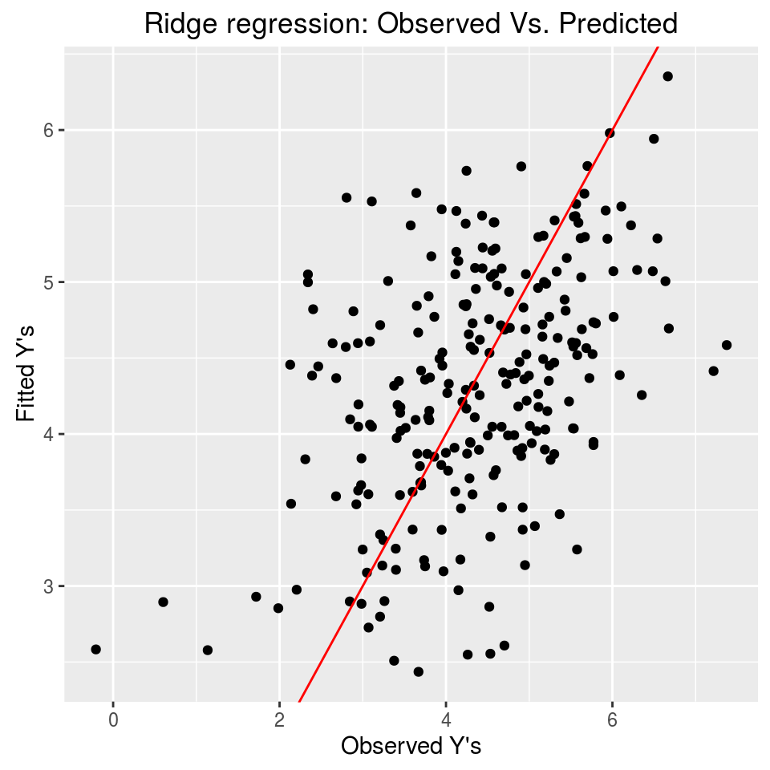

```r
# Plots Observed Vs. Predicted values
ggp <- ggplot(data = data.frame(fit=y_pred_ridge, obs=dt_test$y), mapping = aes(x = obs, y = fit)) +
  geom_point() +
  ggtitle("Ridge regression: Observed Vs. Predicted") +
  xlab("Observed Y's") + ylab("Fitted Y's") +
  geom_abline(slope = 1,intercept = 0, colour="red")
print(ggp)
```

The corresponding mse is given by

```r
mse <- rbind(mse, summary((y_pred_ridge - dt_test$y)^2))
rownames(mse)[nrow(mse)] <- "Ridge"
mse
```

```
##                  Min. 1st Qu. Median   Mean 3rd Qu.  Max.
## OLS         5.502e-05 0.10830 0.4728 1.1170   1.410 7.904
## Forward     3.975e-08 0.08743 0.5400 1.0660   1.312 8.055
## Backward    9.430e-05 0.07594 0.4815 1.0820   1.434 7.904
## Best subset 3.138e-05 0.08001 0.4327 0.9901   1.257 9.426
## Ridge       6.115e-05 0.11120 0.4699 1.1160   1.417 7.847
```

We can see that, at least in this case, ridge regression is not able to produce very accurate predictions. This is probably due to an overfitting effect, since no variable selection has been performed. We could try to first select the variables using one of above methods, and then, if a collinearity between predictors appears, apply ridge regression.

Finally, the coefficient estimates, compared with the OLS one:

```r
coef(ridge_fit)
```

```
##                        x1           x2           x3           x4           x5           x6           x7
##  4.564206065  0.171217780  0.752689035 -0.841833190  0.918003545 -0.922795450  0.398038115  0.009383683
##           x8           x9          x10          x11          x12          x13          x14          x15
## -0.314087123  0.045254267 -0.093916772 -0.082006862 -0.194818921  0.235382397 -0.066855085  0.195528037
##          x16          x17          x18          x19          x20          x21          x22          x23
##  0.241254586  0.182483997  0.160646836 -0.061379544  0.024289772  0.001423604  0.165668972 -0.012991546
##          x24          x25          x26          x27          x28          x29          x30          x31
## -0.113877569  0.153072000 -0.210286533 -0.064020354  0.040036941 -0.301965658 -0.285998125  0.022451583
##          x32          x33          x34          x35          x36          x37          x38          x39
##  0.419057021  0.119951986  0.042216496 -0.107067934 -0.138240502 -0.072345820 -0.147841418  0.071484729
##          x40          x41          x42          x43          x44          x45          x46          x47
##  0.151057716  0.031629678  0.068838867 -0.103683310 -0.134828817 -0.212843898  0.046044220  0.108288536
##          x48          x49          x50          x51          x52          x53          x54          x55
##  0.070729344 -0.075930507 -0.124653900 -0.206119424 -0.062819965  0.184759712 -0.002870848  0.137316951
##          x56          x57          x58          x59          x60          x61          x62          x63
## -0.166452360 -0.064448526 -0.070567365 -0.473279421 -0.159299967 -0.158243270  0.147076443  0.012763957
##          x64          x65          x66          x67          x68          x69          x70          x71
##  0.039078954  0.033794605  0.071668275 -0.057443025 -0.256358134  0.217837803 -0.081205102 -0.129024877
##          x72          x73          x74          x75          x76          x77          x78          x79
##  0.026593892 -0.190419005  0.007785748  0.187117991 -0.143568424 -0.019583309  0.159349870 -0.095478237
##          x80          x81          x82          x83          x84          x85          x86          x87
## -0.076825761 -0.190196499  0.248742734  0.210464494 -0.153388418 -0.079574572  0.219173445  0.218766709
##          x88          x89          x90          x91          x92          x93          x94          x95
## -0.107066707 -0.033493553 -0.148061847 -0.008496576 -0.008714486  0.111012437  0.237621080 -0.084237922
##          x96          x97          x98          x99         x100
##  0.012915122 -0.050960329  0.077795360 -0.124810443 -0.013280684
```

```r
coef(ols_fit)
```

```
##   (Intercept)            x1            x2            x3            x4            x5            x6
##  4.554598e+00 -8.184867e+03  8.185792e+03  1.636923e+04  2.455603e+04 -3.274107e+04  3.966557e-01
##            x7            x8            x9           x10           x11           x12           x13
##  1.043753e-02 -3.142982e-01  4.646501e-02 -9.436869e-02 -8.235240e-02 -1.933035e-01  2.338397e-01
##           x14           x15           x16           x17           x18           x19           x20
## -6.621789e-02  1.971669e-01  2.418587e-01  1.828703e-01  1.601200e-01 -6.066572e-02  2.442740e-02
##           x21           x22           x23           x24           x25           x26           x27
##  1.705178e-03  1.657073e-01 -1.286298e-02 -1.132467e-01  1.536564e-01 -2.078384e-01 -6.218156e-02
##           x28           x29           x30           x31           x32           x33           x34
##  4.129922e-02 -3.009394e-01 -2.880375e-01  2.455323e-02  4.194059e-01  1.197200e-01  4.035049e-02
##           x35           x36           x37           x38           x39           x40           x41
## -1.070110e-01 -1.378742e-01 -7.095531e-02 -1.486828e-01  7.267380e-02  1.512610e-01  3.144402e-02
##           x42           x43           x44           x45           x46           x47           x48
##  7.002959e-02 -1.029584e-01 -1.361565e-01 -2.135883e-01  4.533494e-02  1.090698e-01  7.068811e-02
##           x49           x50           x51           x52           x53           x54           x55
## -7.659557e-02 -1.246505e-01 -2.063320e-01 -6.245864e-02  1.847112e-01 -3.096848e-03  1.373437e-01
##           x56           x57           x58           x59           x60           x61           x62
## -1.667900e-01 -6.331507e-02 -6.838094e-02 -4.741700e-01 -1.592034e-01 -1.578461e-01  1.481105e-01
##           x63           x64           x65           x66           x67           x68           x69
##  1.137715e-02  3.890117e-02  3.263870e-02  7.085531e-02 -5.794235e-02 -2.563530e-01  2.197900e-01
##           x70           x71           x72           x73           x74           x75           x76
## -8.131378e-02 -1.285530e-01  2.701582e-02 -1.903253e-01  8.408269e-03  1.880994e-01 -1.437923e-01
##           x77           x78           x79           x80           x81           x82           x83
## -1.928596e-02  1.595883e-01 -9.460945e-02 -7.883728e-02 -1.903944e-01  2.508786e-01  2.124139e-01
##           x84           x85           x86           x87           x88           x89           x90
## -1.552876e-01 -7.718571e-02  2.184278e-01  2.194058e-01 -1.066971e-01 -3.361988e-02 -1.451596e-01
##           x91           x92           x93           x94           x95           x96           x97
## -1.069872e-02 -9.042297e-03  1.102316e-01  2.375148e-01 -8.373576e-02  1.280358e-02 -5.122576e-02
##           x98           x99          x100
##  7.946681e-02 -1.247622e-01 -1.428846e-02
```

As we can see, the estimated coefficients are more similar to the true ones than many other techniques previusly used.

## (6) Principal Components Regression

We now explore two methods that transform the predictors and then fit a least squares model using the transformed variables. The first approach is called principal component regression (PCR), which first constructs the principal components of the matrix of $X$ variables, and then used these as the predictors in a least squares linear regression model. In PCR it is hence assumed that the directions in which $X1$,…,$Xp$ show the most variation are the directions that are associated with $Y$. While this assumption is not guaranteed to be true, it often turns out to be a reasonable enough approximation.

In PCR, the number of principal components, is typically chosen by cross- validation. The `pls` package contains a function, `pcr()`, that implements the approach we just described:

```r
require(pls)
```

```r
pcr_fit <- pcr(y ~ ., data = dt_train, validation = "CV")
```

We now select the number of components (by CV)

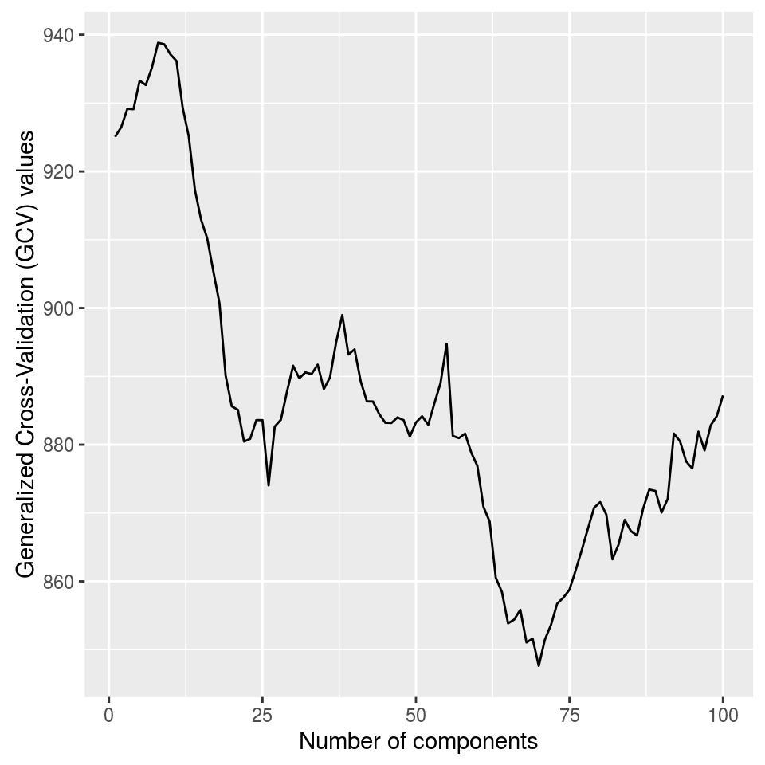

```r
# Plot of CV components values with its RSS:
ggp <- ggplot(data = data.frame(comps=1:100, t(pcr_fit$validation$PRESS)), mapping = aes(x=comps, y=y)) +
  geom_line() +
  xlab("Number of components") + ylab("Generalized Cross-Validation (GCV) values")
print(ggp)
```

```r
(ncomp <- which.min(pcr_fit$validation$PRESS))
```

```
## [1] 70
```

Surprisingly, the number of components selected by PCR is equal to 70 (by definition of predictors’ matrix, there is only a variable correlated with the others, and about 94 non useful predictors). We can then calculate the predicted values

```r
y_pred_pcr <- as.vector(predict(pcr_fit, dt_test, ncomp = ncomp))
mse <- rbind(mse, summary((y_pred_pcr - dt_test$y)^2))
rownames(mse)[nrow(mse)] <- "PCR"
mse
```

```
##                  Min. 1st Qu. Median   Mean 3rd Qu.  Max.
## OLS         5.502e-05 0.10830 0.4728 1.1170   1.410 7.904
## Forward     3.975e-08 0.08743 0.5400 1.0660   1.312 8.055
## Backward    9.430e-05 0.07594 0.4815 1.0820   1.434 7.904
## Best subset 3.138e-05 0.08001 0.4327 0.9901   1.257 9.426
## Ridge       6.115e-05 0.11120 0.4699 1.1160   1.417 7.847
## PCR         6.133e-07 0.08253 0.4457 1.0380   1.252 8.836
```

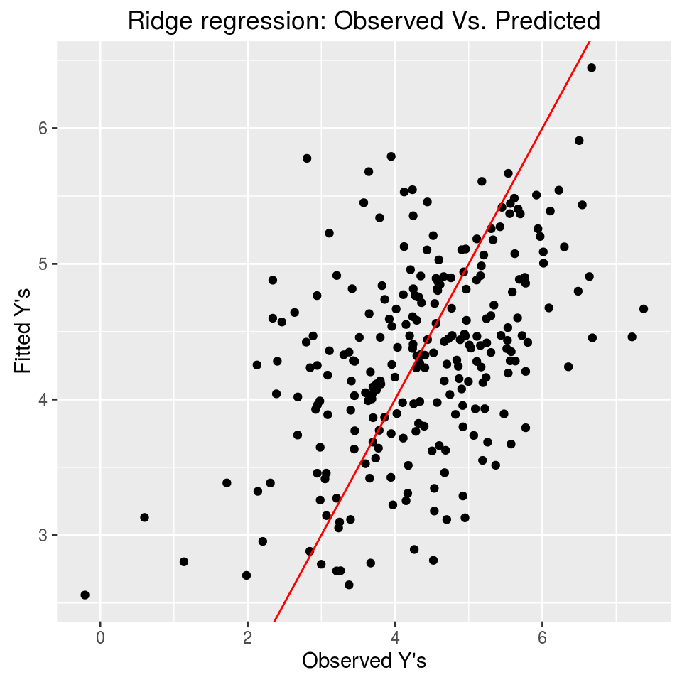

```r
# Plots Observed Vs. Predicted values
ggp <- ggplot(data = data.frame(fit=y_pred_pcr, obs=dt_test$y), mapping = aes(x = obs, y = fit)) +
  geom_point() +
  ggtitle("Ridge regression: Observed Vs. Predicted") +
  xlab("Observed Y's") + ylab("Fitted Y's") +
  geom_abline(slope = 1,intercept = 0, colour="red")
print(ggp)
```

In this case, the results are better than the ones of OLS and backward and forward stepwise.  
A possibile step ahead could be to try to reduce the model starting from the matrix of 70 principal components.

## (7) Partial Least Squares (PLS)

As we already pointed out, in PCR there is no guarantee that the directions that best explain the predictors will also be the best directions to use for predicting the response. In other words, in finding the components, the response Y is not used.

Partial least squares (PLS), instead, identifies the components in a supervised way, that is, it makes use of the response $Y$ in order to identify new features that not only approximate the old features well, but also that are related to the response. Roughly speaking, the PLS approach attempts to find directions that help explain both the response and the predictors. As with PCR, the number of partial least squares directions used in PLS is a tuning parameter that is typically chosen by cross-validation. Actually, PLS splits the model in two “chunks”:  
$X=TP^T + E$  
$Y=UQ^T + F$  
Where $E$ and $F$ are error matrices, $P$ and $Q$ are factor loadings, and $T$ and $U$ are factor scores.  
PLS try to maximize the correlation between $T$ and $U$.  
$Y$ can be multivariate.  
Also, PLS can deal without any problems with data in which the number of cases $n$ is much less than the number $p$ of independent variables (e.g., NIR spectrum analysis)

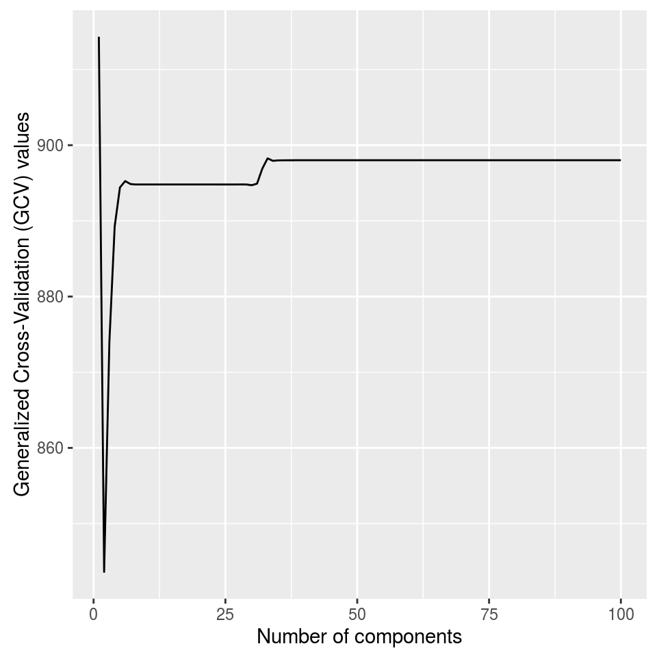

```r
pls_fit <- as.vector(plsr(y ~ ., data = dt_train, validation = "CV"))
# Plot of CV components values with its RSS:
ggp <- ggplot(data = data.frame(comps=1:100, t(pls_fit$validation$PRESS)), mapping = aes(x=comps, y=y)) +
  geom_line() +
  xlab("Number of components") + ylab("Generalized Cross-Validation (GCV) values")
print(ggp)
```

```r
(ncomp <- which.min(pls_fit$validation$PRESS))
```

```
## [1] 2
```

```r
y_pred_pls <- predict(pls_fit, dt_test, ncomp = ncomp)
mse <- rbind(mse, summary((y_pred_pls - dt_test$y)^2))
rownames(mse)[nrow(mse)] <- "PLS"
mse
```

```
##                  Min. 1st Qu. Median   Mean 3rd Qu.  Max.
## OLS         5.502e-05 0.10830 0.4728 1.1170   1.410 7.904
## Forward     3.975e-08 0.08743 0.5400 1.0660   1.312 8.055
## Backward    9.430e-05 0.07594 0.4815 1.0820   1.434 7.904
## Best subset 3.138e-05 0.08001 0.4327 0.9901   1.257 9.426
## Ridge       6.115e-05 0.11120 0.4699 1.1160   1.417 7.847
## PCR         6.133e-07 0.08253 0.4457 1.0380   1.252 8.836
## PLS         9.196e-08 0.10190 0.4833 1.0570   1.366 8.537
```

PLS reduces even to 2 the number of features (independent variables) in model. The predictive results are almost good, also if the error is between stepwise and PCR results.

## (8) `glmnet` (Elastic-Net)

`glmnet` is a package that fits a generalized linear model via penalized maximum likelihood. The regularization path is computed at a grid of values for the regularization parameter. The algorithm is extremely fast, and can exploit sparsity in the input matrix $X$. It fits linear, logistic and multinomial, Poisson, and Cox regression models.

The *elastic net* approach (in linear model) tries to minimize the following criterion function:
$$\frac{\sum_{i=1}^n \left(y_i - \underline{x}_i^T\underline{\beta} \right)^2}{n} + \lambda \sum_{j=1}^p \left[\alpha | \beta_j| +(1-\alpha) \beta_j^2 \right]$$

Where $\underline{\beta}=(\beta_0, \beta_1, \cdots, \beta_p)^T$, (with $\beta_0$ the intercept), $0 \le \alpha \le1$, and $\lambda$ is the penalty term.

When $\alpha=1$, then the so-called *LASSO* (Least Absolute Shrinkage and Selection Operator) penalty term is used, that is based on $L_1$ norm.  
The use of the $L_1$ penalty causes a subset of the solution coefficients $\beta_j$ to be exactly zero, for a sufficiently large value of the tuning parameter $\lambda$.

When $\alpha=0$, then the above seen *ridge* penalty term is used, that is based on $L_2$ norm.  
The ridge penalty, as already seen, tends to shrink the coefficients of correlated variables toward each other.

Elasticnet is introduced as a compromise between these two techniques, and has a penalty which is a mix of $L_1$ and $L_2$ norms. In the package, $\lambda$ may be estimated by cross-validation, while (currently) $\alpha$ is set by the user.

```r
require(glmnet)
```

```r
set.seed(10)
```

We first search for a “good” value for `lambda`:

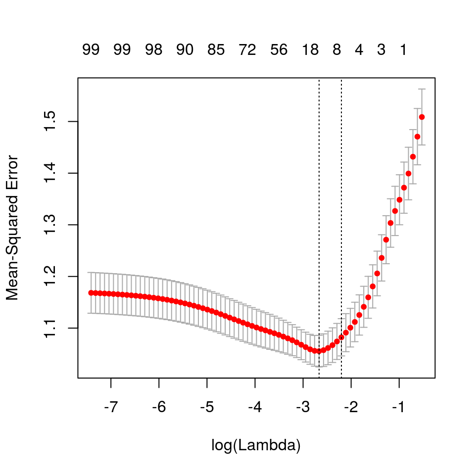

```r
# Set folding parameter
foldid <- sample(rep(seq(10),length=nrow(dt_train)))
cv <- cv.glmnet(x = as.matrix(dt_train[, 1:100]), y = dt_train$y, alpha = 0.9, foldid=foldid)
plot(cv)
```

```r
glmnet_fit <- glmnet(x = as.matrix(dt_train[, 1:100]), y = dt_train$y, lambda = cv$lambda.min, alpha = 0.9)
coef(glmnet_fit)
```

```
## 101 x 1 sparse Matrix of class "dgCMatrix"
##                      s0
## (Intercept)  4.20782729
## x1           0.32915414
## x2           0.30183227
## x3          -1.07302104
## x4           0.26493165
## x5           .
## x6           0.14269794
## x7           .
## x8           .
## x9           .
## x10          .
## x11          .
## x12          .
## x13          0.01360531
## x14          .
## x15          .
## x16          .
## x17          .
## x18          .
## x19          .
## x20          .
## x21          .
## x22          .
## x23          .
## x24          .
## x25          .
## x26          .
## x27          .
## x28          .
## x29         -0.05929504
## x30         -0.05483445
## x31          .
## x32          0.13483365
## x33          .
## x34          .
## x35          .
## x36          .
## x37          .
```

[output cut: 48 more lines]

```
## x86          .
## x87          .
## x88          .
## x89          .
## x90          .
## x91          .
## x92          .
## x93          .
## x94          .
## x95          .
## x96          .
## x97          .
## x98          .
## x99          .
## x100         .
```

```r
y_pred_glmnet <- as.numeric(predict(glmnet_fit, newx = as.matrix(dt_test[, 1:100])))
mse <- rbind(mse, summary((y_pred_glmnet - dt_test$y)^2))
rownames(mse)[nrow(mse)] <- "glmnet"
mse
```

```
##                  Min. 1st Qu. Median   Mean 3rd Qu.  Max.
## OLS         5.502e-05 0.10830 0.4728 1.1170   1.410 7.904
## Forward     3.975e-08 0.08743 0.5400 1.0660   1.312 8.055
## Backward    9.430e-05 0.07594 0.4815 1.0820   1.434 7.904
## Best subset 3.138e-05 0.08001 0.4327 0.9901   1.257 9.426
## Ridge       6.115e-05 0.11120 0.4699 1.1160   1.417 7.847
## PCR         6.133e-07 0.08253 0.4457 1.0380   1.252 8.836
## PLS         9.196e-08 0.10190 0.4833 1.0570   1.366 8.537
## glmnet      1.894e-06 0.11480 0.3934 0.9536   1.146 9.508
```

`cv$lambda.min` returns the value of lambda for which the minimum value of CV error is obtained.

If we want to see what happens when variyng the lambda parameter, we can use the `plot()` method

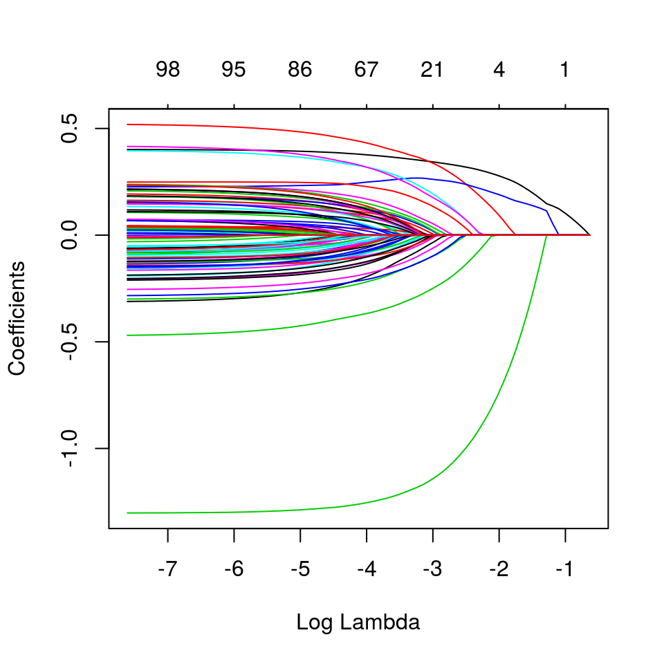

```r
glmnet_fit <- glmnet(x = as.matrix(dt_train[, 1:100]), y = dt_train$y, alpha=1) # default alpha (LASSO)
plot(glmnet_fit,xvar="lambda")
```

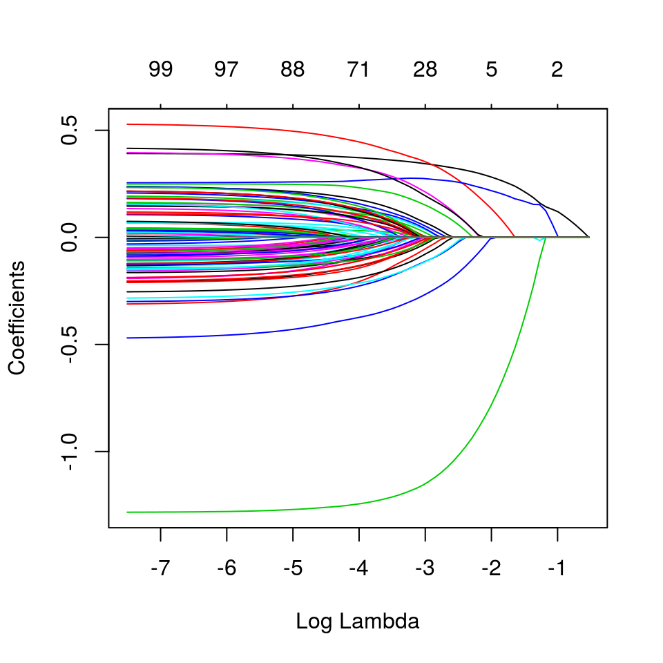

```r
glmnet_fit <- glmnet(x = as.matrix(dt_train[, 1:100]), y = dt_train$y, alpha=0.9) # elastic-net
plot(glmnet_fit,xvar="lambda")
```

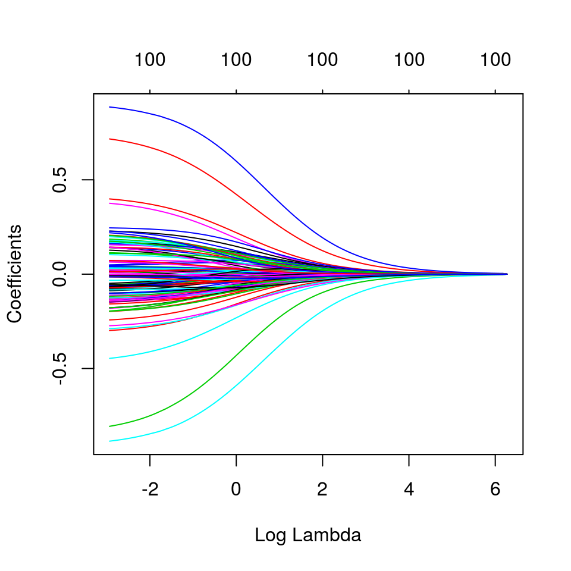

```r
glmnet_fit <- glmnet(x = as.matrix(dt_train[, 1:100]), y = dt_train$y, alpha=0) # ridge
plot(glmnet_fit,xvar="lambda")
```

We now try other combinations of lambda and alpha. Let’s try to use the lambda.1se value obtained from CV:

```r
glmnet_fit <- glmnet(x = as.matrix(dt_train[, 1:100]), y = dt_train$y, lambda = cv$lambda.1se, alpha = 0.9)
y_pred_glmnet <- as.numeric(predict(glmnet_fit, newx = as.matrix(dt_test[, 1:100])))
summary((y_pred_glmnet - dt_test$y)^2)
```

```
##     Min.  1st Qu.   Median     Mean  3rd Qu.     Max.
##  0.00019  0.11670  0.43790  0.96110  1.20300 10.83000
```

Here, we serach for the best `lambda` value for with `alpha = 1`:

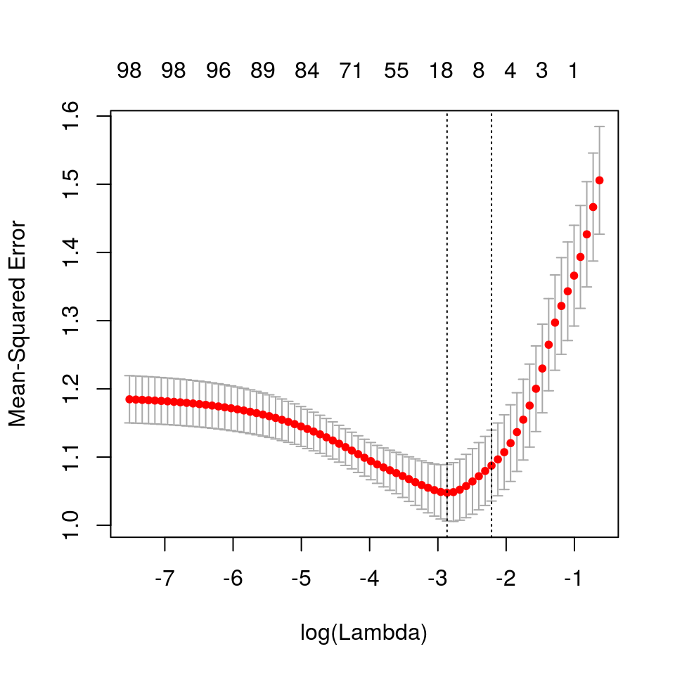

```r
cv <- cv.glmnet(x = as.matrix(dt_train[, 1:100]), y = dt_train$y, alpha = 1)
plot(cv)
```

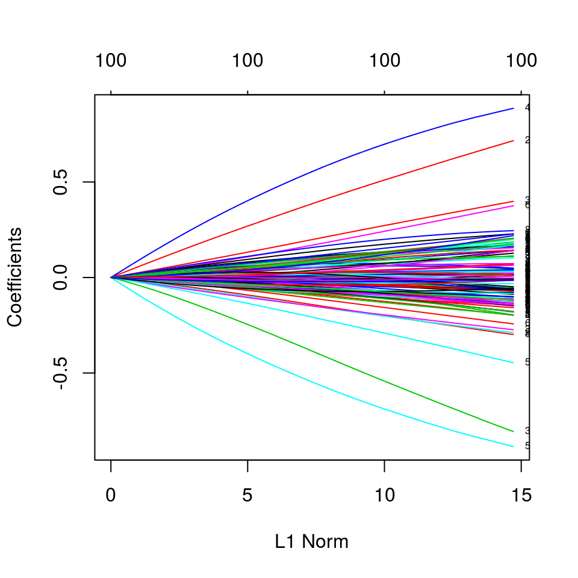

```r
# Plots the model parameters with alpha=0 (ridge) when varying the L1 norm
glmnet_fit <- glmnet(x = as.matrix(dt_train[, 1:100]), y = dt_train$y, alpha = 0)
plot(glmnet_fit, label = TRUE)
```

```r
# Compares the models with alpha=1 (LASSO) with lambda.min and lambda.1se
glmnet_fit <- glmnet(x = as.matrix(dt_train[, 1:100]), y = dt_train$y, lambda = cv$lambda.min, alpha = 1)
y_pred_glmnet <- as.numeric(predict(glmnet_fit, newx = as.matrix(dt_test[, 1:100])))
summary((y_pred_glmnet - dt_test$y)^2)
```

```
##     Min.  1st Qu.   Median     Mean  3rd Qu.     Max.
## 0.000001 0.100200 0.404300 0.956100 1.123000 9.263000
```

```r
glmnet_fit <- glmnet(x = as.matrix(dt_train[, 1:100]), y = dt_train$y, lambda = cv$lambda.1se, alpha = 1)
y_pred_glmnet <- as.numeric(predict(glmnet_fit, newx = as.matrix(dt_test[, 1:100])))
summary((y_pred_glmnet - dt_test$y)^2)
```

```
##      Min.   1st Qu.    Median      Mean   3rd Qu.      Max.
##  0.000026  0.116700  0.445000  0.965100  1.212000 11.120000
```

Now we perform a grid search for the parameters pairs (`lambda`, `alpha`) that produce the best model:

```r
alphas <- (0:101)/101
cv_fits <- lapply(X = alphas,FUN = function(a, dt_train, foldid){
      fit <- cv.glmnet(x = as.matrix(dt_train[, 1:100]), y = dt_train$y, alpha = a, foldid = foldid)
      return(fit)
    },
    dt_train=dt_train, foldid=foldid
  )

mins <- t(sapply(X = cv_fits, FUN = function(x){return(c(lambda=x$lambda.min, cvm=min(x$cvm, na.rm = TRUE) ))}))
wm <- which.min(mins[,"cvm"])
alpha_opt <- alphas[wm]
(opt <- c(alpha=alpha_opt, mins[wm,]))
```

```
##     alpha    lambda       cvm
## 1.0000000 0.0624982 1.0546455
```

```r
glmnet_fit <- glmnet(x = as.matrix(dt_train[, 1:100]), y = dt_train$y, lambda = opt["lambda"], alpha = opt["alpha"])
coef(glmnet_fit, label = TRUE)
```

```
## 101 x 1 sparse Matrix of class "dgCMatrix"
##                      s0
## (Intercept)  4.21834810
## x1           0.33328716
## x2           0.29913892
## x3          -1.08757110
## x4           0.25404565
## x5           .
## x6           0.14370106
## x7           .
## x8           .
## x9           .
## x10          .
## x11          .
## x12          .
## x13          0.01316862
## x14          .
## x15          .
## x16          .
## x17          .
## x18          .
## x19          .
## x20          .
## x21          .
## x22          .
## x23          .
## x24          .
## x25          .
## x26          .
## x27          .
## x28          .
## x29         -0.05987110
## x30         -0.05461579
## x31          .
## x32          0.13526127
## x33          .
## x34          .
## x35          .
## x36          .
## x37          .
```

[output cut: 48 more lines]

```
## x86          .
## x87          .
## x88          .
## x89          .
## x90          .
## x91          .
## x92          .
## x93          .
## x94          .
## x95          .
## x96          .
## x97          .
## x98          .
## x99          .
## x100         .
```

```r
y_pred_glmnet <- as.numeric(predict(glmnet_fit, newx = as.matrix(dt_test[, 1:100])))

mse <- rbind(mse, summary((y_pred_glmnet - dt_test$y)^2))
rownames(mse)[nrow(mse)] <- "best-glmnet"
mse
```

```
##                  Min. 1st Qu. Median   Mean 3rd Qu.  Max.
## OLS         5.502e-05 0.10830 0.4728 1.1170   1.410 7.904
## Forward     3.975e-08 0.08743 0.5400 1.0660   1.312 8.055
## Backward    9.430e-05 0.07594 0.4815 1.0820   1.434 7.904
## Best subset 3.138e-05 0.08001 0.4327 0.9901   1.257 9.426
## Ridge       6.115e-05 0.11120 0.4699 1.1160   1.417 7.847
## PCR         6.133e-07 0.08253 0.4457 1.0380   1.252 8.836
## PLS         9.196e-08 0.10190 0.4833 1.0570   1.366 8.537
## glmnet      1.894e-06 0.11480 0.3934 0.9536   1.146 9.508
## best-glmnet 3.257e-06 0.11120 0.3929 0.9539   1.148 9.448
```

Suprisingly, the best model is not really “best”. Maybe, this could be due to rounding effects. Anyway, the differences between this model and the previous one are really small.